# Week 6 - Kelton Chapter 5 Homework

### 1. What is the difference between an object property and an object state?

An object property is defined within an object to collect information from the user to customize that object’s behavior. Whereas an object state is defined within an object and holds the value of something that might change while a model is running [1].

<sub><sup>[1] Kelton, W. David., Jeffrey S. Smith, and David T. Sturrock. Simio and Simulation: Modeling, Analysis, Applications. Sewickley, PA: Simio Forward Thinking, 2014. Print.</sup></sub>

### 2. Consider a process associated with a Server object. What is the difference between a token’s parent object and it’s associated object?

A token references both its parent object and its associated object. A parent object is an instance of the object in which the process is defined whereas the associated object is the related object that triggered this process to execute [1].

<sub><sup>[1] Kelton, W. David., Jeffrey S. Smith, and David T. Sturrock. Simio and Simulation: Modeling, Analysis, Applications. Sewickley, PA: Simio Forward Thinking, 2014. Print.</sup></sub>

### 3. Develop a queuing model that gives the steady-state values analogous to the values in Table 5.2 (Model 5-1 with exponential processing times at both stations)

Model Design

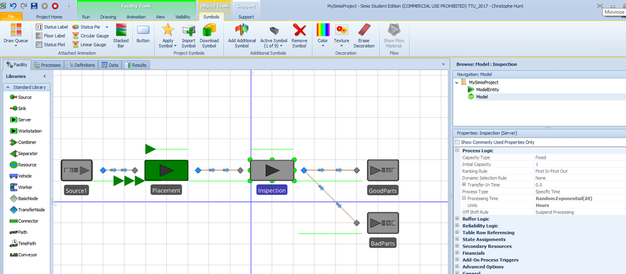

Model Results

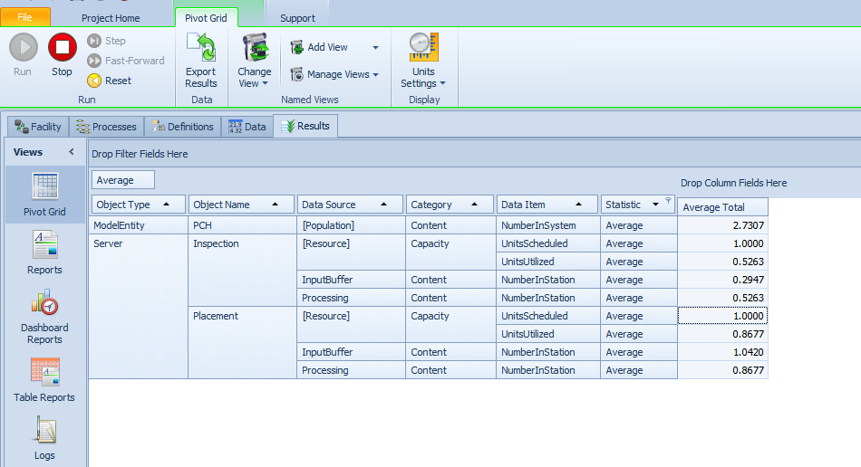

### 4. Consider an office where people come to get their drivers’ license. The process involves three steps for arriving customers - reception/application; a vision exam; and a written exam . Assume that customer arrivals are Poisson with a rate of 6 per hour (i.e. inter-arrival time are exponentially distributed with mean 10 minutes). the processing time distributions for the three processes are given in Table 5.8. the office has some person responsible for reception/application and one person responsible for administering the vision exams. The written exam is computer-based and there are three computer stations where customers can take the exam. Develop a Simio model of this system. Assume that the office opens at 9:00 am and closes at 5:00 pm. The performance metrics of interest include the time that customers spend in the system, the utilization of the office employees and the computer stations, and the average and maximum numbers of customers in the reception/application queue, the vision exam queue, and the written exam queue. How many replications should be run in order to be confident about your results? Justify your answer.

Model

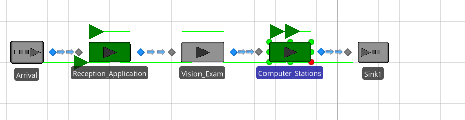

Results

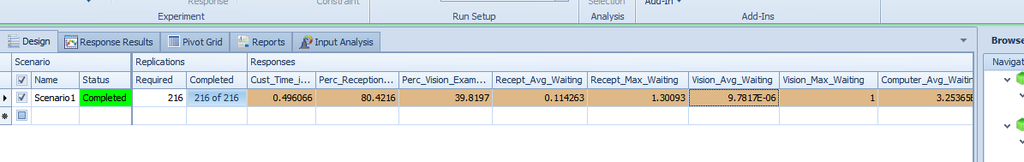

### 5. Animate the model from Problem 4. If you did not already do so, specify a reasonable office layout and us Path object to incorporate customer movement through the office. Make sure that the distances between stations are reasonable for a drivers license office and that the entity speed is appropriate for humans walking.

I chose 2 meters per second instead of the default 1.4 meters per second. A very fast walk is 2.5 meters per second [2], 1.4 meters per second is average, I thought that people would be hoping to get out of the DMV faster and might on average walk slightly faster.

<sub><sup>[2] Preferred walking speed. (2017, September 8). In Wikipedia, The Free Encyclopedia. Retrieved 16:51, October 8, 2017, from https://en.wikipedia.org/w/index.php?title=Preferred_walking_speed&oldid=799557256</sup></sub>

I also made the distance from entrance to eye exam 50 meters, eye exam to computer station 20 meters, and then from computer to exit 40 meters. I think this is reasonable distance.

Model Distances

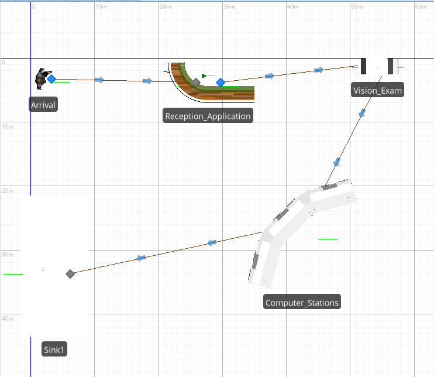

Model Design

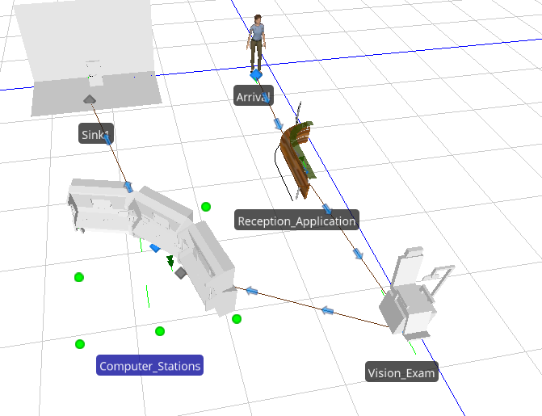

Model Results with distances

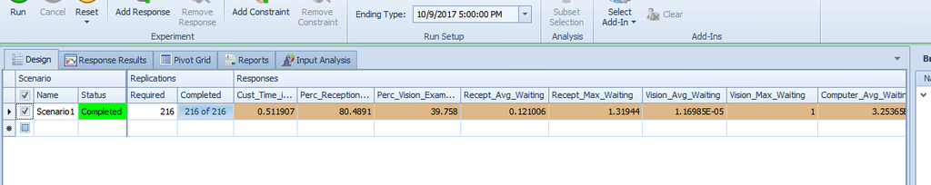